# PG2- Estadística y Probabilidades

El Estado de Nutrición de niños menores de 5 años durante el 2020 en Lima

## INTRODUCCIÓN

*- Relevancia*

La llegada de la pandemia en el 2020 afectó seriamente al mundo. La nutrición de los niños del Perú se vió impactado negativamente. En este proyecto estudiaremos minuciosamente el estado de nutrición de Niños menores de 5 años en Lima durante el 2020.Además, con este estudio lograremos conocer las causas que estuvieron involucradas en el estado de nutrición de nuestra unidad muestral y sacar conclusiones respecto a ellas.

*Objetivos*

**Objetivos generales:**

- Determinar el impacto de la pandemia en el Estado de Nutrición de los niños de Lima durante el año 2020
- Determinar los factores que influyeron en el Estado de Nutrición por la pandemia de la COVID-19 en los niños del Perú

## DATOS

**- Proceso de Recolección de los datos:**

En este caso utilizamos una base datos, dicha base de datos se encuentra en la Plataforma Nacional de Datos Abiertos y se llama Sistema de información del Estado Nutricional de niños y gestantes Perú - INS/CENAN (Instituto Nacional de Salud - Centro Nacional de Alimentación y Nutrición). Luego para definir mejor nuestra muestra y hacer más viable nuestro proyecto escogimos los datos del Estado Nutricional de los niños en el año 2020 (año de la pandemia).. Del mismo modo, se consideró esta base de datos dado que proviene de una plataforma confiable e instituciones avaladas por el Perú.

**- Población, muestra y muestreo**

**Población:** La población que tomamos son las personas de nacionalidad peruana. Claramente decidimos tomar como población a nuestro país porque sabemos donde podemos encontrar la información confiable para nuestro proyecto. Por otro lado, sabemos lo mucho que la pandemia afectó a todo nuestro país y especialmente a nuestra muestra seleccionada.

**Unidad muestral:** La muestra que tomamos son los niños menores de 5 años. Al inicio estábamos buscando información acerca del impacto nutricional en jóvenes de nuestra edad ( 17 a 20 años ) , pero los resultados eran similares a los de años anteriores. Por lo que concluimos que no había tal impacto, por eso optamos por el análisis en niños.

### LIMPIEZA DE DATOS

- Primero empezamos con una base de datos que contiene información del estado de nutrición de niños menores a 5 años de todo el Perú, leemos la base de datos con la función read.csv.

```r
library(readr)
library(ggplot2)
data<-read.csv("DataFramePG1.csv",sep=";")
#View(data)
```

- Eliminamos variables (columnas) que no serán necesarias en nuestro proyecto con la función select de la librería dplyr, luego añadimos la variable Edad(años) al data frame con la función Mutate.

```r
library(dplyr)
DataFrame1 <- select(data,-Microred,-EESS,-Dpto_EESS,-Dist_EESS,-Renipress,-FechaAtencion,-UbigeoPN,-FechaNacimiento,-DepartamentoPN,-ProvinciaPN,-DistritoPN,-CentroPobladoPN,-FechaHemoglobina,-UbigeoREN,-DepartamentoREN,-ProvinciaREN,-AlturaREN,-Prov_EESS,-DistritoREN)
#View(DataFrame1)
```

```r
DataFrame1=mutate(DataFrame1,Edadaños=as.integer(EdadMeses/12))
```

- Filtramos la base de datos para trabajar solo con los datos de los niños del departamento de Lima

```r
DataFrame2 <- filter(DataFrame1, Diresa %in% c("LIMA DIRIS CENTRO","LIMA DIRIS ESTE","LIMA DIRIS NORTE","LIMA DIRIS SUR", "LIMA"))
```

- Utilizamos una función llamada remove_outliers, la cual reemplaza por un na a los valores atípicos, esta función utilizamos conceptos de quantiles y rango intercuartil.

```r
remove_outliers <- function(x, na.rm = TRUE, ...) {
  qnt <- quantile(x, probs=c(.25, .75), na.rm = na.rm, ...)
  H <- 1.5 * IQR(x, na.rm = na.rm)
  y <- x
  y[x < (qnt[1] - H)] <- NA
  y[x > (qnt[2] + H)] <- NA
  y
}
```

- Aplicamos la función llamada remove_outliers para las variables que necesitan eliminar datos atípicos, en este caso las variables peso y talla. Anteriormente se vió que necesitaban de una eliminación de datos atípicos con la función range.

```r
set.seed(1)
DataFrame_nueva<-DataFrame2
DataFrame_nueva$Peso <- remove_outliers(DataFrame_nueva$Peso)
DataFrame_nueva$Talla <- remove_outliers(DataFrame_nueva$Talla)
#View(DataFrame_nueva)
```

- Eliminamos todas las observaciones que tengan algún NA.

```r
DataFrame_nueva <- na.omit(DataFrame_nueva)
#View(DataFrame_nueva)
```

- Por último, re-nombramos variables, en caso de que el nombre de alguna sea muy ambigua o confusa.

```r
colnames(DataFrame_nueva)[1:18] <-c("Diresa","Red","Sexo","Edad(meses)","Juntos","SIS","Pin","Qaliwarma","Peso(kg)","Talla(cm)","Hemoglobina","Cred","Suplementación","Consejería","Sesión","Hbc","Anemia","Edad(años)")
View(DataFrame_nueva)
```

## Análisis descriptivo

### Descriptores numéricos

```r
cat('Número de observaciones:', nrow(DataFrame_nueva),'\n')
```

```
## Número de observaciones: 42895
```

TABLA 1: Anemia vs Diresa**

| Diresa | Normal | Anemia Leve | Anemia Moderada | Anemia Severa | Total |
| --- | --- | --- | --- | --- | --- |
| LIMA | 10577 | 1446 | 781 | 17 | 12821 |
| LIMA DIRIS CENTRO | 3779 | 854 | 260 | 1 | 4894 |
| LIMA DIRIS ESTE | 2981 | 1084 | 374 | 0 | 4439 |
| LIMA DIRIS NORTE | 7201 | 2435 | 859 | 9 | 10504 |
| LIMA DIRIS SUR | 7012 | 2393 | 824 | 8 | 10237 |
| TOTAL | 31550 | 8212 | 3098 | 35 | 42895 |

Según la tabla 1, podemos decir:

```r
cat('Moda de la variable Diresa según el tipo de anemia que tiene cada niño:','Anemia normal -',31550 , '\n')
```

```
## Moda de la variable Diresa según el tipo de anemia que tiene cada niño: Anemia normal - 31550
```

**- Variable Sexo.**

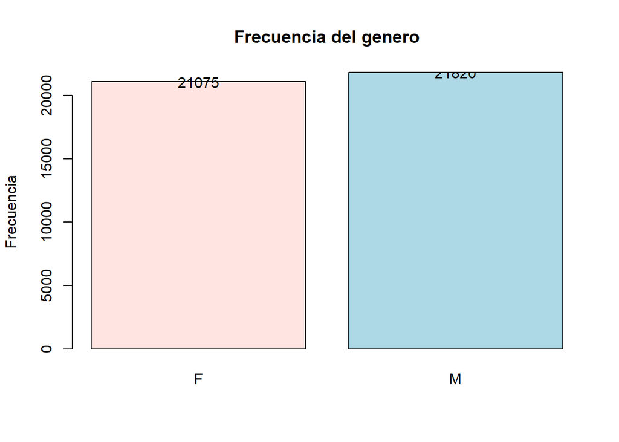

```r
a<-table(DataFrame_nueva$Sexo)
barp<-barplot(a,beside=TRUE,main = "Frecuencia del genero", xlab='', ylab='Frecuencia',col = c("mistyrose", "lightblue"))
text(barp, a-7.25, labels = a)
```

```r
table(DataFrame_nueva$Sexo)
```

```
##
##     F     M
## 21075 21820
```

```r
cat('Moda de la variable Sexo:', "Maculino", '\n')
```

```
## Moda de la variable Sexo: Maculino
```

**Variable Edad(meses)**

```r
summary(DataFrame_nueva$`Edad(meses)`)
```

```
##    Min. 1st Qu.  Median    Mean 3rd Qu.    Max.
##    6.00   12.00   20.00   23.34   31.00   60.00
```

**-Variable Talla(cm)**

```r
summary(DataFrame_nueva$`Talla(cm)`)
```

```
##    Min. 1st Qu.  Median    Mean 3rd Qu.    Max.
##   48.00   74.00   81.90   82.55   90.00  116.00
```

**- Variable Peso(kg)**

```r
summary(DataFrame_nueva$`Peso(kg)`)
```

```
##    Min. 1st Qu.  Median    Mean 3rd Qu.    Max.
##    3.60    9.89   11.57   11.97   13.98   20.27
```

**- Promedio de hemoglobina y HBC de acuerdo al nivel de anemia.**

Lo que haremos será sacar el promedio de la la hemoglobina de acuerdo al tipo de anemia.

```r
DataFrame_nueva %>% group_by(Anemia) %>% summarise(Hemoglobina=mean(Hemoglobina, na.rm = T), Hbc=mean(Hbc, na.rm=T))
```

[output not shown]

**-Promedio de Talla y Peso de acuerdo a la edad.**

```r
DataFrame_nueva %>% group_by(`Edad(años)`) %>% summarise(Talla=mean(`Talla(cm)`, na.rm = T), Peso=mean(`Peso(kg)`, na.rm=T))
```

[output not shown]

### Descriptores gráficos

#### - **Género**

**Anemia de acuerdo al sexo:** En este caso analizamos dos variables categóricas, la variable del sexo y el nivel de anemia, para ver si se presenta alguna relación entre ambas variables o si hay algún sexo en particular que tenga mayor frecuencia de anemia.

```
##
##  Femenino Masculino
##     21075     21820
```

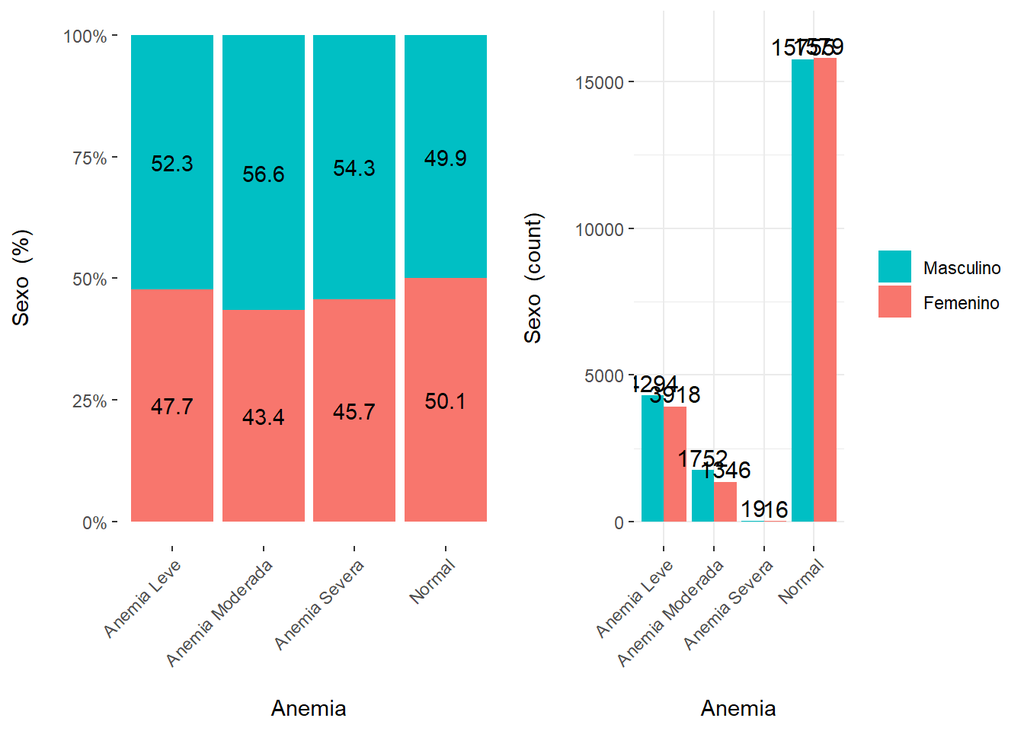

En este caso, en la gráfica podemos ver que no hay ninguna relación, pues la frecuencia de anemia de acuerdo al sexo es similar, es decir se presenta por igual en ambos sexos.

#### - **Edad**

Gráficos de barras de anemia de acuerdo a la edad.

Año 0.

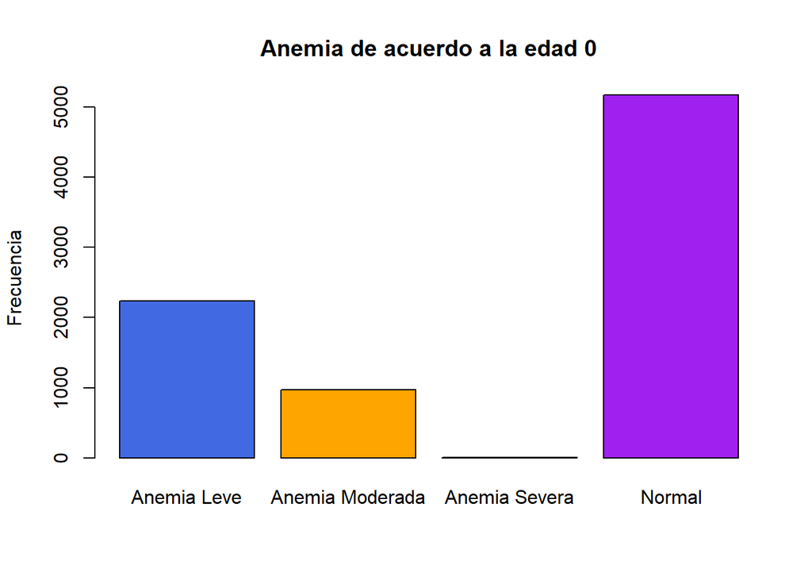

Año 1.

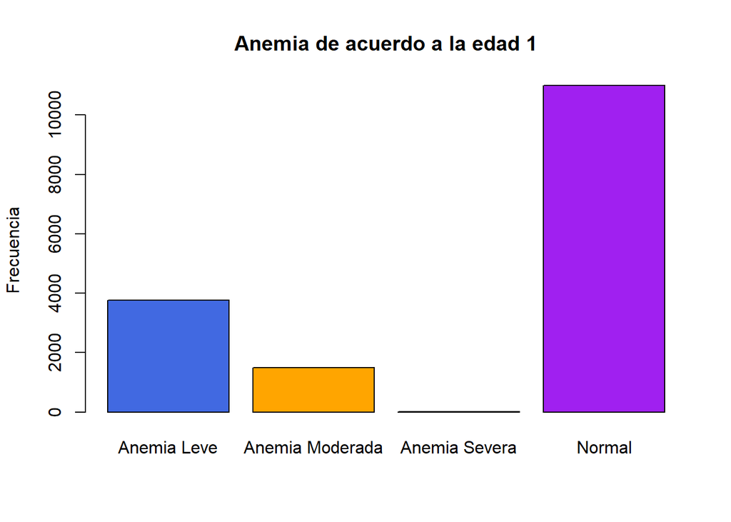

Año 2.

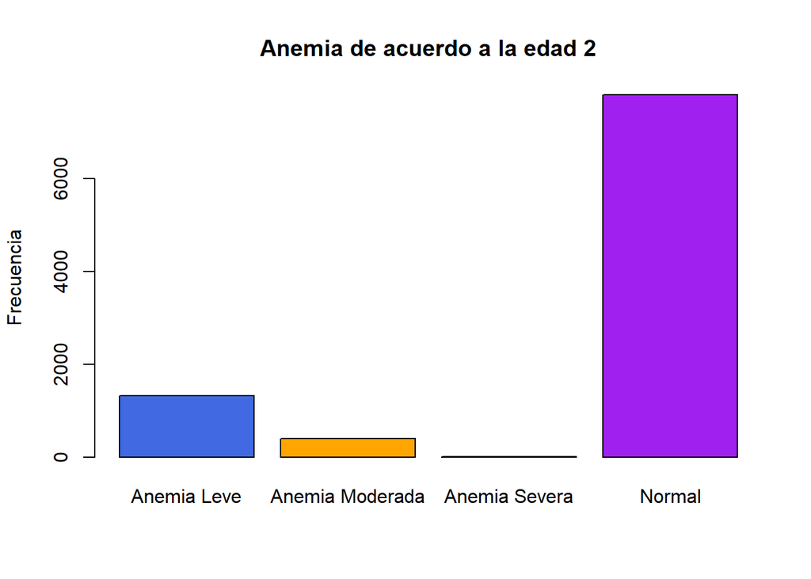

Año 3.

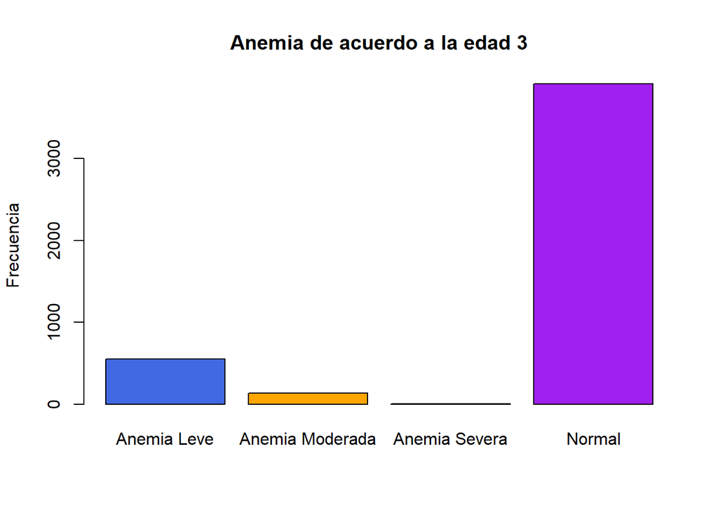

Año 4.

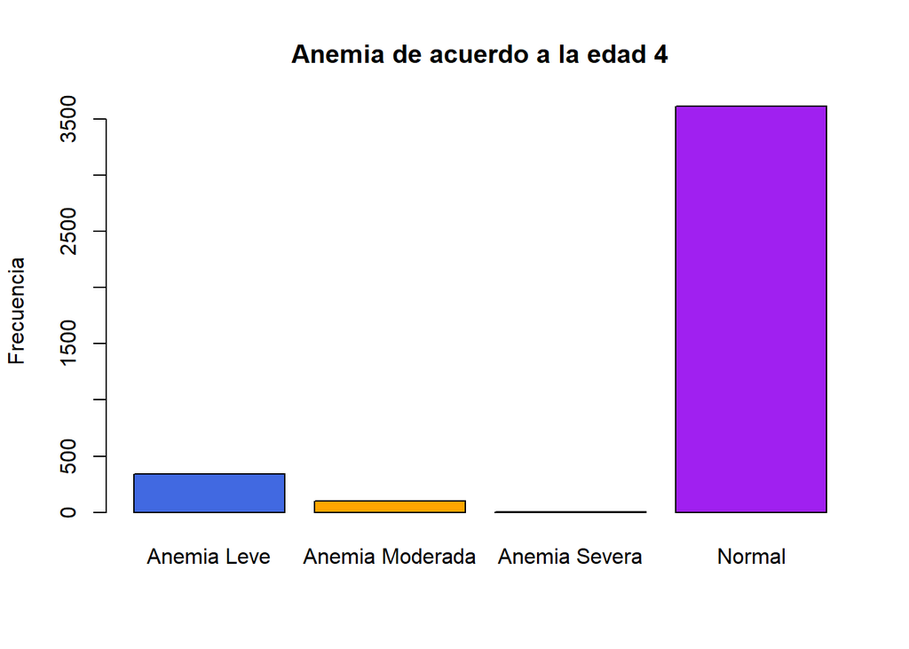

Año 5.

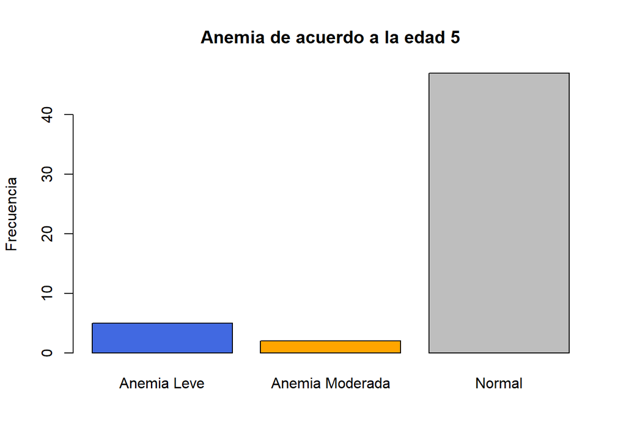

Con estos gráficos podemos ver como varía la frecuencia de los niños con Anemia de acuerdo a su edad.

### - **Anemia de acuerdo al lugar**

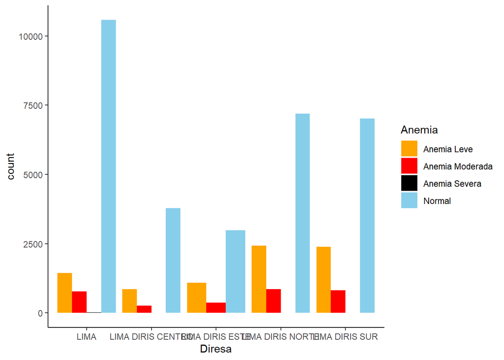

```r
library(ggplot2)
g1 <- ggplot(DataFrame_nueva,aes(x=Diresa)) + geom_bar(aes(fill=Anemia),position="dodge") + theme_classic()+ scale_fill_manual(values=c("orange","red","black","skyblue"))
g1 + scale_fill_manual(values=c("orange","red","black","skyblue"))
```

- OJITO: Anemia Normal = Niño Sano

**Conclusiones:**

1. La anemia severa tiene la frecuencia mas baja en todas las Diresas.
2. De los 31550 casos de anemia normal , la Diresa Lima tiene mayor frecuencia.
3. La anemia normal en todas las Diresas es mayor al doble de la anemia moderada.

### DIRESA Y CONSEJERIA

Las variables DIRESA y Consejeria son categoricas, y en el siguiente grafico evaluaremos en que parte de LIMA se recibieron mayor Consejeria respecto al tema de Nutrición de niños menores de 5 años.

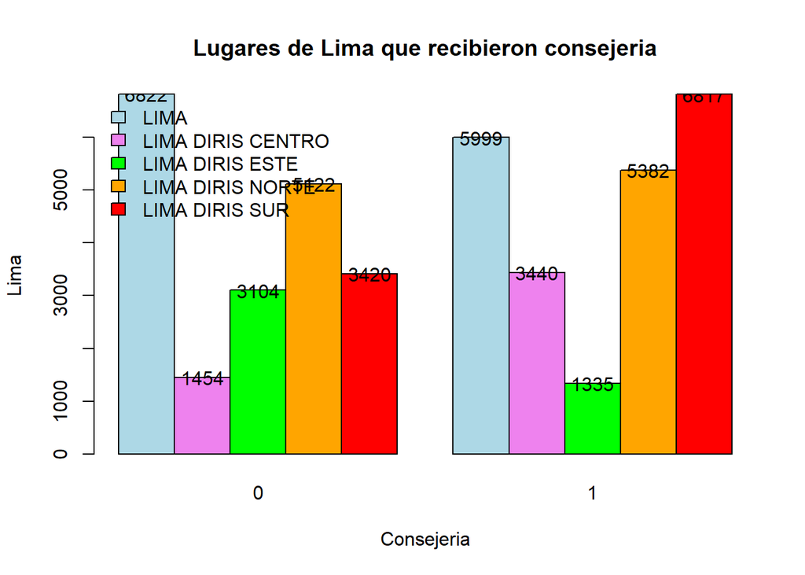

```r
b<-table(DataFrame_nueva$Diresa,DataFrame_nueva$Consejería)
barp<-barplot(b,beside=TRUE,main = "Lugares de Lima que recibieron consejeria", xlab='Consejeria', ylab='Lima',col = c("lightblue", "violet","green","orange","red"))
text(barp, b-2, labels = b)
legend('topleft', legend=rownames(b), bty='n',
       fill=c("lightblue", "violet","green","orange","red"))
```

Según el grafico, los niños que vivian por LIMA SUR recibian mayor consejeria que los niños que vivian por LIMA ESTE.

### DIRESA y SIS

Las variables Diresa y SIS son categóricas y en este caso las analizamos para verificar en que parte de LIMA la mayoría de niños tenían un seguro Integral de Salud y por lo contrario en que lugar no tenian.

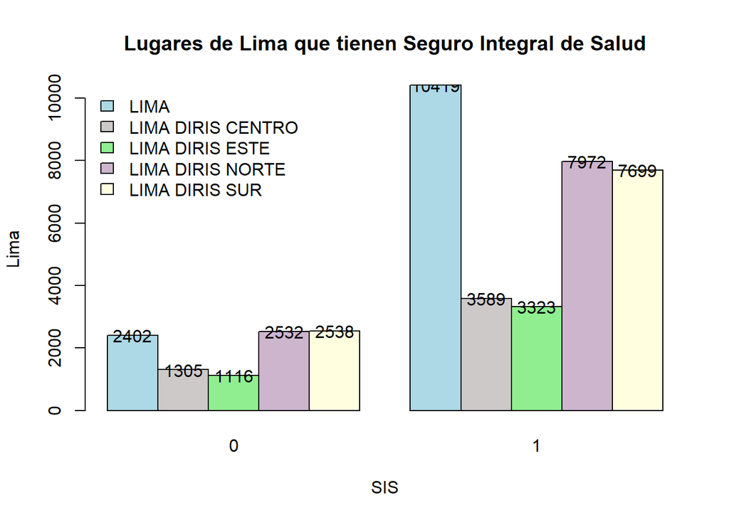

```r
b<-table(DataFrame_nueva$Diresa,DataFrame_nueva$SIS)
barp<-barplot(b,beside=TRUE,main = "Lugares de Lima que tienen Seguro Integral de Salud", xlab='SIS', ylab='Lima',col = c("lightblue", "snow3","lightgreen","thistle3","lightyellow"))
text(barp, b-2, labels = b)
legend('topleft', legend=rownames(b), bty='n',
       fill=c("lightblue", "snow3","lightgreen","thistle3","lightyellow"))
```

## ANÁLISIS PROBABILISTICO

#### 1. PROBABILIDAD FRECUENTISTA

Para realizar un buen análisis frecuentista, construiremos dos tablas de doble entrada para en base a eso analizar de mejor nuestras variables y por lo tanto, nuestras probabilidades. La primera tabla relacionará las variables de Anemia y Diresa, la segunda tabla relacionará las variables de sexo y hemoglobina.

##### **TABLA 1: Anemia vs Diresa**

| Diresa | Normal | Anemia Leve | Anemia Moderada | Anemia Severa | Total |
| --- | --- | --- | --- | --- | --- |
| LIMA | 10577 | 1446 | 781 | 17 | 12821 |
| LIMA DIRIS CENTRO | 3779 | 854 | 260 | 1 | 4894 |
| LIMA DIRIS ESTE | 2981 | 1084 | 374 | 0 | 4439 |
| LIMA DIRIS NORTE | 7201 | 2435 | 859 | 9 | 10504 |
| LIMA DIRIS SUR | 7012 | 2393 | 824 | 8 | 10237 |
| TOTAL | 31550 | 8212 | 3098 | 35 | 42895 |

La leyenda para hallar las probabilidades es la siguiente:

- LC = Lima Diris Centro
- LE = Lima Diris Este
- LN= Lima Diris Norte
- LS= Lima Diris Sur
- L = Lima
- N = Normal
- A1= Anemia Leve
- A2= Anemia Moderada
- A3= Anemia Severa

Empezamos con la probabilidades:

1. ¿Cuál es la probabilidad de que un niño tenga anemia leve y residan en Lima Diris Norte?

$$P(A1 \cap LN) = 2435/42895 = 0.0568 =
5.68\%$$

2. ¿Cuál es la probabilidad de que un niño no tengan anemia y pertenezcan a Lima Diris Sur?

$$P(N \cap LS) = 7012/42895 = 0.1635 =
16.35\%$$

3. ¿Cuál es la probabilidad de que un niño tenga anemia y pertenezcan a Lima?

$$P(N^c \cap L) = P((A1 \cup A2 \cup A3)
\cap L)= 2244/42895 = 0.0523 = 5.23\%$$

4. ¿Cuál es la probabilidad de que un niño tenga anemia?

$$P(N^c) = P(A1 \cup A2 \cup A3)=
\frac{8212}{42895} + \frac{3098}{42895} + \frac{35}{42895} = 0.2645 =
26.45\%$$

$$P(N^c) = 1 - P(N) = 1- 31550/42895 =
0.2645 = 26.45\%$$

5. ¿Cuál es la probabilidad de que un niño tenga anemia moderada y pertenezca a Lima?

6. ¿Cuál es la probabilidad de que no pertenezca a Lima Diris Norte?

$$P(LN^c) = 1 - P(LN) = 1- 10504/42895 =
0.7551 = 75.51\%$$
7. ¿Cuál es la probabilidad de que tenga anemia leve dado que pertenezca a Lima Diris Sur?

$$P (A1 | LS) = \frac{P (A1 \cap
LS)}{P(LS)} = \frac{2393/42895}{10237/42895} = \frac{2393}{10237} =
0.2338 = 23.38\%$$

8. ¿Cuál es la probabilidad de que tenga anemia moderada dado que es Lima Diris Este?

$$P (A2 | LE) = \frac{P (A2 \cap
LE)}{P(LE)} = \frac{374/42895}{4439/42895} = \frac{374}{4439} = 0.0843
= 8.43\%$$

##### **TABLA 2: Sexo vs Nivel de hemoglobina**

Primero categorizamos la variable continua de Hemoglobina con las siguientes condiciones, para niños de la edad con la que estamos trabajando:

Normal: >10.9

Leve: 10-10.9

Moderada: 7-9.9

Grave: <7

Las cuales fueron obtenidas de un artículo realizado por Jessica Yunconza.

| Sexo | Normal | Leve | Moderada | Grave | Total |
| --- | --- | --- | --- | --- | --- |
| FEMENINO | 16338 | 3557 | 1164 | 16 | 21075 |
| MASCULINO | 16338 | 3958 | 1505 | 19 | 21820 |
| TOTAL | 32676 | 7515 | 2669 | 35 | 42895 |

La leyenda para hallar las probabilidades es la siguiente:

- F = Femenino
- M = Masculino
- HN = Nivel de hemoglobina normal
- HM = Nivel de hemoglobina moderada
- HG = Nivel de hemoglobina grave

Empezamos con la probabilidades:

1. Si elegimos aleatoriamente a un niño ¿Cual es la probabilidad de que sea del sexo femenino y tenga nivel de hemoglobina moderada?

2. Si elegimos aleatoriamente a un niño ¿Cual es la probabilidad de que sea del sexo masculino y tenga nivel de hemoglobina normal?

$$P(M \cap HN) = 16338/42895 = 0.3809 =
38.09\%$$

3. Si elegimos aleatoriamente a un niño ¿Cual es la probabilidad de que sea del sexo femenino y no tenga nivel de hemoglobina normal?

$$P(F \cap HN^c) = P(F \cap HL) + P(F \cup
HM) + P(F \cup HG) = \frac{3557}{42895} + \frac{1664}{42895} +
\frac{16}{42895} = \frac{4737}{42895} = 0.1104 = 11.04\%$$

4. Si elegimos aleatoriamente a un niño ¿Cual es la probabilidad de que sea del sexo masculino y no tenga nivel de hemoglobina normal?

$$P(M \cap HN^c) = P(M \cap HL) + P(M \cup
HM) + P(M \cup HG) = \frac{3958}{42895} + \frac{1505}{42895} +
\frac{19}{42895} = \frac{5482}{42895} = 0.1278 = 12.78\%$$

5. Si elegimos aleatoriamente a un niño ¿Cual es la probabilidad de que tenga nivel de hemoglobina grave dado que es del sexo masculino?

$$P(HG | M ) = \frac{P (HG \cap M)}{P(M)}
= \frac{19/42895}{21820/42895} = \frac{19}{21820} = 0.0009 =
0.09\%$$

5. Si elegimos aleatoriamente a un niño ¿Cual es la probabilidad de que tenga nivel de hemoglobina leve dado que es del sexo femenino?

$$P(HL | F ) = \frac{P (HL \cap F)}{P(F)}
= \frac{3557/42895}{21075/42895} = \frac{3557}{21075} = 0.1688 =
16.88\%$$

6. Si elegimos aleatoriamente a un niño ¿Cual es la probabilidad de que sea del sexo masculino dado que tiene un nivel de hemoglobina normal?

$$P(M | HN ) = \frac{P (M \cap
HN)}{P(HN)} = \frac{16338/42895}{32676/42895} = \frac{16338}{32676} =
0.5 = 50\%$$

7. Si elegimos aleatoriamente a un niño ¿Cual es la probabilidad de que sea del sexo femenino dado que tiene un nivel de hemoglobina leve?

$$P(F | HL ) = \frac{P (F \cap
HL)}{P(HL)} = \frac{3557/42895}{7515/42895} = \frac{3557}{7515} =
0.4733 = 47.33\%$$

8. Si elegimos aleatoriamente a un niño ¿Cual es la probabilidad de que no sea del sexo masculino?

$$P(M^c) = P(F) = 1- P(M) = 1 -
\frac{21820}{42895} = 0.4913 = 49.13\%$$

**RESULTADOS**

Podemos concluir que realizando este tipo de tablas de los datos obtenidos, podemos agilizar el análisis y obtención de las respectivas probabilidades, las cuales nos permitirán desarrollar predicciones a futuro.

De este manera, en base a nuestra probabilidades, podemos sacar algunas conclusiones, en las cuales también hay que considerar que es una aproximación y tiene un margen de error, pues estamos trabajando con una muestra.

#### 2. MODELOS PROBABILISTICOS

##### Obejetivos propuestos:

- Encontrar relaciones entre las variables para así poder plantear correctas distribuciones probabilisticas .
- Determinar un análisis de posibilidad de ocurrencia de los eventos con la teoría de métodos probabilisticos aprendida y practicada en clase.

##### - DISTRIBUCIÓN BINOMIAL:

Caso1: Analizaremos la variable Anemia, en la cual observaremos la cantidad de niños según el estado de anemia en el que se encuentran. En cual se divide en 4 tipos, anemia Leve(8212 niños), Moderada(3098), Severa(35 niños) y los niños que se encuentran con una hemoglobina adecuada(Normal, 31550 niños) de un total de 42895 niños.

En este caso vamos a determinar la probabilidad de que dentro de un grupo de 85 niños, más de 25 se encuentran con anemia Leve dado que viven en Lima Diris Este. Asimismo, buscaremos hallar el valor esperado de nuestra función probabilidad, su varianza y su desviación estándar:

P(x > 25), p=1084/4439, n = 85

```r
table(DataFrame_nueva$Diresa)
```

```
##
##              LIMA LIMA DIRIS CENTRO   LIMA DIRIS ESTE  LIMA DIRIS NORTE
##             12821              4894              4439             10504
##    LIMA DIRIS SUR
##             10237
```

```r
table(DataFrame_nueva$Anemia)
```

```
##
##     Anemia Leve Anemia Moderada   Anemia Severa          Normal
##            8212            3098              35           31550
```

Probabilidad (1 - pbnimon(x, n, p)):

```r
1-pbinom(25,85,1084/4439)
```

```
## [1] 0.1170346
```

Valor esperado

```r
85*(1084/4439)
```

```
## [1] 20.75693
```

VARIANZA

```r
85*(1084/4439)*(1-(1084/4439))
```

```
## [1] 15.6881
```

Desviación estándar

```r
(85*(1084/4439)*(1-1084/4439))^0.5
```

```
## [1] 3.960821
```

Funcion de probabilidad

```r
n=85
p=1084/4439
valor=25

dbinom(valor,size=n,prob=p)
```

```
## [1] 0.05457938
```

```r
library(ggplot2)
rango = 0:n
df = data.frame(x = rango, y = dbinom(rango, size=n, prob=p))
```

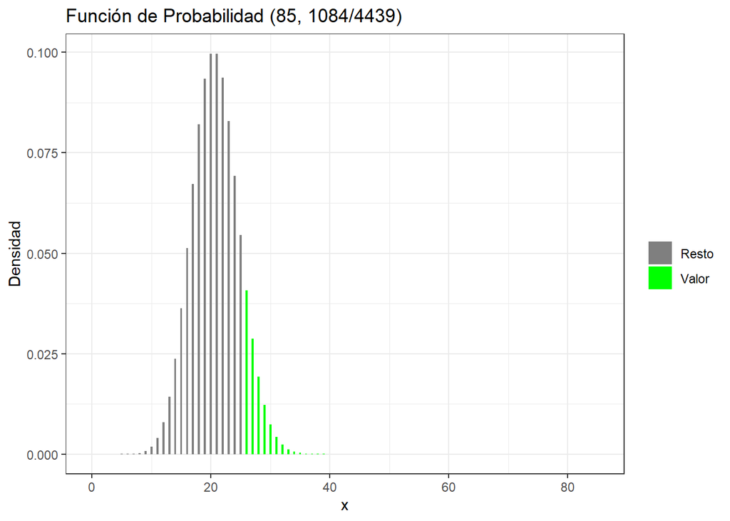

```r
ggplot(df, aes(x = x, y = y, fill=factor(ifelse(x>valor,"Valor","Resto")))) +
geom_bar(stat = "identity",width=0.35) + xlab("x") + ylab("Densidad") +
ggtitle("Función de Probabilidad (85, 1084/4439)") +
scale_fill_manual(name = "", values=c("grey50","green")) + theme_bw()
```

#### - Distribución Hipergeométrica

Caso 2: Si se extrae una muestra aleatoria de 75 niños del total de los niños que se tiene en la base de datos para una estudio de una empresa informática. ¿Cúal es la probabilidad de que de estos 75 niños exactamente 58 estudiantes tengan SIS?

1. Hallamos la cantidad de niños con SIS en total

```r
nrow(filter(DataFrame_nueva,DataFrame_nueva$SIS == 1))
```

```
## [1] 33002
```

2. Hallamos la cantidad de niños sin SIS en total. (Tenemos 2 formas)

```r
nrow(filter(DataFrame_nueva,DataFrame_nueva$SIS == 0))
```

```
## [1] 9893
```

```r
nrow(DataFrame_nueva)-nrow(filter(DataFrame_nueva,DataFrame_nueva$SIS == 1))
```

```
## [1] 9893
```

3. Planteamos un modelo, en este caso sería la distribución hipergeométrica ya que se extrae una muestra de toda la población.
1. Definimos los parámetros que utilizaremos
- x (seleccion) = 58
- m (exitos)= 33002
- n (fracasos)= 9893
- k ( muestra ) = 75

$$P(X=58)$$

```r
m = 33002
n = 9893
k = 75
dhyper(58,33002,9893,75)
```

```
## [1] 0.1091831
```

Entonces la probabilidad sería: 0.1092 o 10.92%

La función de probabilidad es:

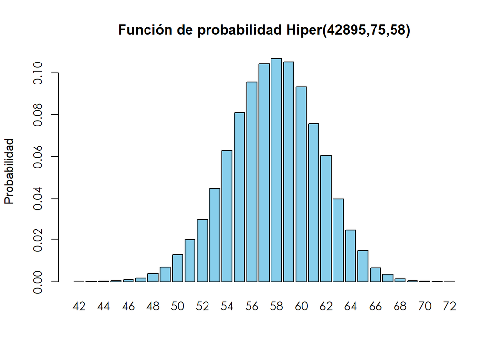

```r
datos<-rhyper(m+n,m,n,k)
barplot(prop.table(table(datos)),col=c("skyblue"),main="Función de probabilidad Hiper(42895,75,58)", ylab ="Probabilidad", las=0,font.axis=14)
```

Además, la sección de informática de la empresa desea hallar los siguientes descriptores numéricos de dispersión.

1. Varianza ( Tenemos dos formas )

```r
varianza1<- n*p*(1-p)*choose(42895-75,42894)
varianza1
```

```
## [1] 0
```

```r
varianza2<-(75 * p)*choose(42895-33002,42895)*choose(42895-75,42895-1)
varianza2
```

```
## [1] 0
```

2.Desviación estándar

```r
desv = sqrt(varianza1)
desv
```

```
## [1] 0
```

3. Valor esperado -> nr/N

```r
(75*33002)/42895
```

```
## [1] 57.70253
```

#### - Distribución Geométrica

Hallando la probabilidad de niños sin anemia (Normal)

Cant. total de niños que no tienen anemia (Normal) = 31550

```r
n_sin_anemia <- sum(DataFrame_nueva$Anemia=="Normal")
n_sin_anemia
```

```
## [1] 31550
```

Población total de niños = 42895

```r
poblacion <- nrow(DataFrame_nueva)
poblacion
```

```
## [1] 42895
```

Por lo tanto nuestra probabilidad de niños sin anemia (p) será:

```r
p <- n_sin_anemia/poblacion
p
```

```
## [1] 0.735517
```

p = 0.735517 ~ 73.55%

Pregunta de probabilidad 1:

En el departamento de Lima, la probabilidad de encontrar a un niño de entre 0 a 5 años que no tengan anemia es del 73.55% ¿Cuál es la probabilidad de que el tercer niño que analicemos, este sea el primero que no tenga anemia? solución: x = 3 p = 0.7355

dgeom( x - 1, p)

```r
dgeom(2,p)
```

```
## [1] 0.05145035
```

La probabilidad de que el primer niño sin anemia sea el tercer niño que se analiza es del 0.05145035 ~ 5.15%

Función de probabilidad:

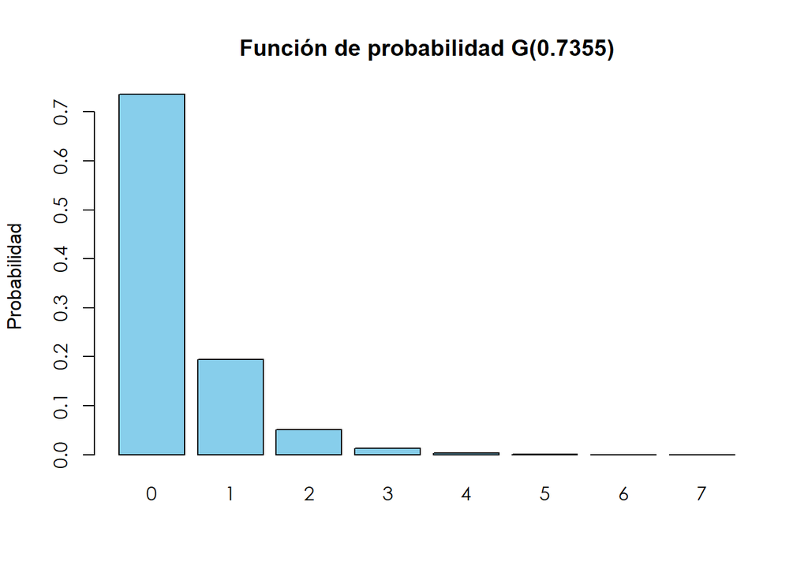

```r
datos_geom<-rgeom(42895,p)
barplot(prop.table(table(datos_geom)),col=c("skyblue"),main="Función de probabilidad G(0.7355)", ylab ="Probabilidad", las=0,font.axis=14)
```

Además,se tiene los siguientes descriptores numéricos de dispersión.

1. Valor esperado

```r
esperanza<-1/p
esperanza
```

```
## [1] 1.359588
```

Tenemos que esperar 1.36 ensayos hasta obtener el primer acierto incluido el ensayo que es acierto.

```r
esperanza<-(1-p)/p
esperanza
```

```
## [1] 0.359588
```

Tenemos que esperar 0.36 fracasos para llegar al primer acierto.

2. Varianza

```r
varianza<-(1/p)*((1/p)-1)
varianza
```

```
## [1] 0.4888915
```

3. Desviación estándar

```r
desv = sqrt(varianza)
desv
```

```
## [1] 0.6992077
```

#### Distribución normal

Caso 4: Hallando una distribución normal analizando el dato de la talla en los niños que tienen la edad de 3.

Para obtener la distribución normal, primero filtramos los datos, para tener la data solo de los niños que tienen 3.

```r
pob_3<-filter(DataFrame_nueva,DataFrame_nueva$`Edad(años)` == 3)
```

Luego, mediante el siguiente código mediante la función sample y saply, obtenemos el vector muestra, el cual contiene los promedios de la talla de los niños de 3 años de 5000 muestras sacadas aleatoriamente del total de niños que tienen 3 años.

```r
muestra<-sapply(1:5000, function(x){mean(sample(pob_3$`Talla(cm)`,1000,rep=T))})
```

Realizamos el histograma del vector muestra.

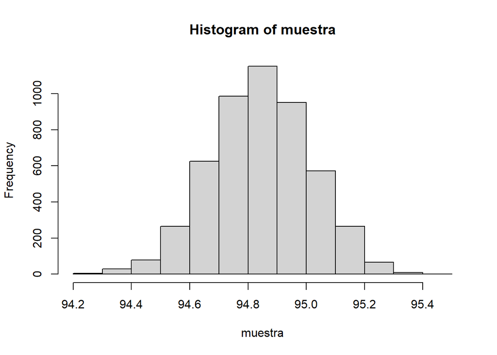

```r
hist(muestra)
```

Del mismo modo, para probar normalidad, usaremos la prueba shapiro Wilks:

```r
shapiro.test(muestra)
```

```
##
##  Shapiro-Wilk normality test
##
## data:  muestra
## W = 0.99921, p-value = 0.02356
```

Ho: Los datos provienen de una población con distribución normal

H1: Los datos no provienen de una población con distribución normal

Luego obtenemos los datos de la media y desviación estándar para definir los parámetros de la distribución normal sobre la que trabajaremos:

```r
media<-mean(muestra)
media
```

```
## [1] 94.84376
```

```r
sd<-sd(muestra)
sd
```

```
## [1] 0.1702281
```

Pregunta de probabilidad:

En el departamento de Lima, un programa del Estado que tiene como objetivo reducir los niveles de anemia, desea saber la talla promedio de los niños de Lima, para lo cual realiza un estudio experimental de tamaño de muestra x. ¿Cuál es la probabilidad de que el promedio de la talla de los niños de la muestra de tamaño x sea mayor o igual a 95?

Solución:
$$P(X\geq95)$$

```r
pnorm(95,media,sd,lower.tail = F)
```

```
## [1] 0.1793596
```

Función de densidad:

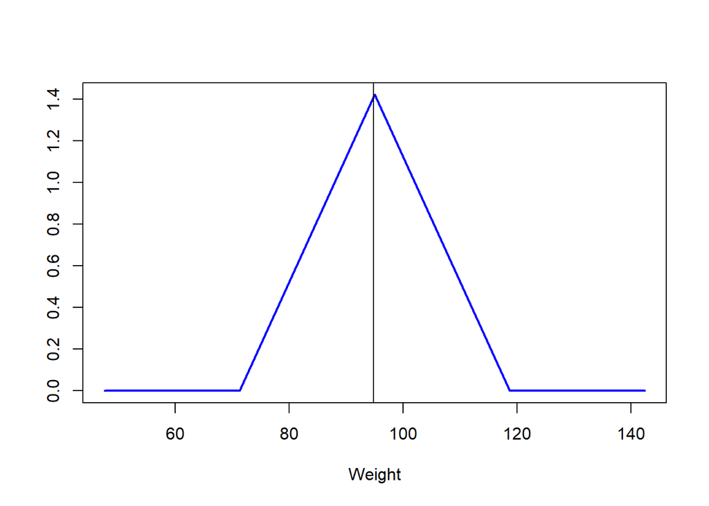

```r
# Grid para una distribución normal no estándar
x <- seq(0.5, 1.5, length = 5) * media + sd

# Función de densidad
f <- dnorm(x, media, sd)

plot(x, f, type = "l", lwd = 2, col = "blue", ylab = "", xlab = "Weight")
abline(v = media) # Línea vertical en la media
```

## REFERENCIAS BIBLIOGRAFICAS

-Instituto Nacional de la salud (2021). SISTEMA DE INFORMACIÓN DEL ESTADO NUTRICIONAL de niños y gestantes Perú - INS/CENAN. Plataforma Nacional de Datos Abiertos. Consultado el 5 de septiembre del 2022. https://www.datosabiertos.gob.pe/dataset/sistema-de-informaci%C3%B3n-del-estado-nutricional-de-ni%C3%B1os-y-gestantes-per%C3%BA-inscenan-instituto.

-Yunconza, J. (2019). Cuáles son los valores normales de hemoglobina en sangre. unCOMO. Consultado el 25 de noviembre. https://www.mundodeportivo.com/uncomo/salud/articulo/cuales-son-los-valores-normales-de-hemoglobina-en-sangre-46677.html.